# DAKD2023_ex2_Ruslan_Hasanov

## Please fill up the asked information!

Name: Ruslan Hasanov

Student number: 1.2.246.562.24.87458088684

Mail: ruhasa@utu.fi

# Data Analysis and Knowledge Discovery: Exercise 2, Supervised learning

The previous exercise was about *data understanding* and *data preparation*, which formed the basis for the modeling phase of the data mining process. Many modeling techniques make assumptions about the data, so the exploration and preparation phases can't be ignored. Now, as we have checked the validity of data and familiarized ourselves with it, we can move on to the next stage of the Cross-Industry Standard Process for Data Mining (CRISP-DM), which is modeling.

The questions to be answered at this stage could include:

- What kind of model architecture best fits our data?
- How well does the model perform technically?
- Could we improve its performance?
- How do we evaluate the model's performance?

*Machine learning* is a subfield of artificial intelligence that provides automatic, objective and data-driven techniques for modeling the data. Its two main branches are *supervised learning* and *unsupervised learning*, and in this exercise, we are going to use the former, supervised learning, for classification and regression tasks.

For classification, data remains the same as in the previous exercise, but I've already cleaned it up for you. Some data pre-processing steps are still required to ensure that it's in an appropriate format so that models can learn from it. Even though we are not conducting any major data exploration nor data preparation this time, *you should **never** forget it in your future data analyses*.

**General guidance for exercises**

- Answer **all** questions below, even if you can't get your script to fully work.
- Write clear and easily readable code, and include explanations what your code does.
- Make informative illustrations: include labels for x and y axes, legends and captions for your plots.
- You can add more code and markup cells, as long as the flow of the notebook stays readable and logical.
- **A complete submission includes a working notebook**, so it's highly recommended to run "Restart & Run all" before the final save. Remember to submit BOTH versions of the exercise (ipynb AND html/pdf).
- Grading: *Fail*/*Pass*/*Pass with honors* (+1)
  - Passing requires that **the parts 1-5** are completed.
  - +1 bonus point (grading *Pass with honors*) requires a **completely** correct solution and also thorough analysis.
- If you encounter problems, Google first. Always give the credit where it belongs so please **cite your sources, whether you're referencing text or code**. You will learn so much more when you have to research and summarize information in your own words. If you can't find an answer to the problem, don't hesitate to ask in the Moodle discussion or directly via email (tuhlei@utu.fi).
- Note! Don't leave it to the last moment! No feedback service during weekends.
- **We do not encourage the use of ChatGPT or similar models**, but if you choose to do so, always be critical of the outputs and try to comprehend them before any use. Also, make a brief description how you utilized the model (what was your input and how did you benefit from the output).

The guided exercise session is held on the 28th of November at 14:15-16:00, at TSE Elovena-Sali.

**The deadline is the 30th of November at 23:59**. Late submissions will not be accepted unless there is a valid excuse for an extension which should be asked **before** the original deadline.

### Gather all packages needed for this notebook here:

You can use other packages as well, but this excercise can be completed with those below.

```python
import numpy as np
import pandas as pd

# Visualization packages - matplotlib and seaborn
# Remember that pandas is also handy and capable when it comes to plotting!
import seaborn as sns
import matplotlib.pyplot as plt

# Machine learning package - scikit-learn
from sklearn import metrics
from sklearn.preprocessing import StandardScaler
from sklearn.model_selection import train_test_split, cross_val_score, LeaveOneOut, GridSearchCV
from sklearn.neighbors import KNeighborsClassifier, KNeighborsRegressor
from sklearn.linear_model import Ridge, LinearRegression
# Show the plots inline in the notebook
%matplotlib inline
```

## 1. Classification using k-nearest neighbors

We start exploring the world of data modeling by using the K-Nearest Neightbors (k-NN) algorithm. The k-NN algorithm is one of the classic supervised machine learning algorithms which assumes that similar points are close to each other.

In our case, we'll use the k-NN algorithm to *predict the presence of cardiovascular disease* (CVD) using all the other variables as features in the given data set. I.e. the target variable that we are interested in is `cardio`.

But first, we need data for the task. The code for loading the data into the environment is provided for you. The code should work but make sure that you have the CSV file of the data in the same directory where you have this notebook file.

**Exercise 1 A)**

Take a random sample of 1500 rows from the dataframe using your student id as a seed. Print the first 15 rows to check that everything is ok with the dataframe.

*Note: as mentioned, the data remains the same, but cholesterol has been one-hot-encoded for you already. There's also a new variable, gluc (about glucose levels), which is one-hot-encoded for you. It has similar values as cholesterol originally had [normal, at risk, elevated].*

```python
### Loading code provided
# ------------------------------------------------------
# The data file should be at the same location than the
# exercise file to make sure the following lines work!
# Otherwise, fix the path.
# ------------------------------------------------------

# Path for the data
data_path = r'C:\Users\Comp-servis\Desktop\ex2_cardio_data.csv'

# Read the CSV file
cardio_data = pd.read_csv(data_path)
```

```python
### Code - Resample and print 15 rows
student_id_seed = 2310614

# Taking a random sample of 1500 rows and resetting the index of new Data Frame
cardio_sample = cardio_data.sample(n=1500, random_state=student_id_seed).reset_index(drop=True)

# Printing the first 15 rows
cardio_sample.head(15)
```

|  | age | gender | height | weight | ap_hi | ap_lo | smoke | alco | active | cardio | cholesterol_normal | cholesterol_elevated | cholesterol_high | gluc_normal | gluc_elevated | gluc_high |
| --- | --- | --- | --- | --- | --- | --- | --- | --- | --- | --- | --- | --- | --- | --- | --- | --- |
| 0 | 43 | 1 | 164 | 78.0 | 120 | 80 | 0 | 0 | 1 | 0 | 1 | 0 | 0 | 1 | 0 | 0 |
| 1 | 55 | 1 | 149 | 49.0 | 120 | 80 | 0 | 0 | 1 | 0 | 1 | 0 | 0 | 1 | 0 | 0 |
| 2 | 49 | 1 | 157 | 79.0 | 120 | 80 | 0 | 0 | 1 | 1 | 1 | 0 | 0 | 0 | 1 | 0 |
| 3 | 55 | 1 | 187 | 65.0 | 120 | 80 | 0 | 0 | 1 | 0 | 1 | 0 | 0 | 1 | 0 | 0 |
| 4 | 40 | 1 | 165 | 59.0 | 130 | 80 | 0 | 0 | 1 | 1 | 1 | 0 | 0 | 1 | 0 | 0 |
| 5 | 45 | 1 | 150 | 63.0 | 100 | 70 | 0 | 0 | 1 | 1 | 0 | 1 | 0 | 1 | 0 | 0 |
| 6 | 49 | 1 | 169 | 72.0 | 120 | 80 | 0 | 0 | 0 | 1 | 1 | 0 | 0 | 1 | 0 | 0 |
| 7 | 42 | 1 | 161 | 59.0 | 120 | 80 | 0 | 0 | 1 | 0 | 1 | 0 | 0 | 1 | 0 | 0 |
| 8 | 57 | 1 | 160 | 65.0 | 130 | 80 | 0 | 0 | 1 | 0 | 1 | 0 | 0 | 1 | 0 | 0 |
| 9 | 45 | 2 | 179 | 69.0 | 120 | 80 | 0 | 0 | 1 | 0 | 1 | 0 | 0 | 1 | 0 | 0 |
| 10 | 39 | 1 | 163 | 58.0 | 110 | 70 | 0 | 0 | 1 | 0 | 0 | 0 | 1 | 0 | 0 | 1 |
| 11 | 44 | 1 | 165 | 65.0 | 120 | 80 | 0 | 0 | 1 | 0 | 1 | 0 | 0 | 1 | 0 | 0 |
| 12 | 54 | 2 | 156 | 56.0 | 120 | 80 | 0 | 0 | 0 | 1 | 1 | 0 | 0 | 1 | 0 | 0 |
| 13 | 51 | 1 | 159 | 69.0 | 120 | 80 | 0 | 0 | 1 | 0 | 1 | 0 | 0 | 1 | 0 | 0 |
| 14 | 45 | 2 | 172 | 97.0 | 140 | 90 | 0 | 0 | 1 | 1 | 1 | 0 | 0 | 1 | 0 | 0 |

We have the data so now, let's put it to use.

To teach the k-NN algorithm (or any other machine learning algorithm) to recognize patterns, we need training data. However, to assess how well a model has learned these patterns, we require test data which is new and unseen by the trained model. It's important to note that the test set is not revealed to the model until after the training is complete.

So, to *estimate the performance of a model*, we may use a basic train-test split. The term "split" is there because we literally split the data into two sets.

**Exercise 1 B)**

Collect the features as an array named `features`, and the target variable as an array named `labels`. Create training and test data by randomly splitting the data into training (80%) and test (20%) sets.

- Do you need stratification for our dataset? Explain your decision.

```python
### Code - Train-test split

# collecting the features as an array named features
features = cardio_sample.drop(columns=['cardio'])

# collecting the target variable as an array named labels
labels = cardio_sample['cardio']

# splitting the data intro training (80%) and test (20%) sets
x_train, x_test, y_train, y_test = train_test_split(features, labels, test_size=0.2)

# Displaying the frequency count for each unique value in labels data
print(pd.value_counts(labels))

# Displaying the percentage distribution of each class in labels data
class_percentage = np.bincount(labels) / len(labels) * 100
print('Percentage of Each Class in Labels Data\n', class_percentage)

# Displaying the frequency count for each unique value in y_test data
print(pd.value_counts(y_test))

# Displaying the percentage distribution of each class in y_test data
class_percentage = np.bincount(y_test) / len(y_test) * 100
print('Percentage of Each Class in y_test Data\n',class_percentage)

# Displaying the frequency count for each unique value in y_train data
print(pd.value_counts(y_train))

# Displaying the percentage distribution of each class in y_train data
class_percentage = np.bincount(y_train) / len(y_train) * 100
print('Percentage of Each Class in y_train Data\n',class_percentage)
```

```
0    1052
1     448
Name: cardio, dtype: int64
Percentage of Each Class in Labels Data
 [70.13333333 29.86666667]
0    215
1     85
Name: cardio, dtype: int64
Percentage of Each Class in y_test Data
 [71.66666667 28.33333333]
0    837
1    363
Name: cardio, dtype: int64
Percentage of Each Class in y_train Data
 [69.75 30.25]
```

Stratification is important to ensure that we have similar distributions of classes or categories in training and test sets. I think that this method is not necessary in my case, since I have slightly different proportions of the classes in labels, y_test and y_train data.

**Exercise 1 C)**

Standardize the numerical features: Note that you should now have two separate features that you've divided all the features into.

- Describe how the k-NN model would make predictions about whether or not a patient has a CVD when the features are not standardized, and explain the reasons behind.

*Note: Some good information about preprocessing and how to use it for train and test data can be found https://scikit-learn.org/stable/modules/preprocessing.html*.

```python
### Code - Standardization

# Importing the standardization function 'scale'
from sklearn.preprocessing import scale

# Creating a list of the names of the numerical features in the given dataframe
numerical_features = ["age", "height", "weight", "ap_hi", "ap_lo"]

# standardizing the numerical features in x_train data
x_train[numerical_features] = scale(x_train[numerical_features])

# standardizing the numerical features in x_test data
x_test[numerical_features] = scale(x_test[numerical_features])
```

In K-NN models, the similarity between data points is measured based on the distance metric. The distance calculation will be dominated by the features with the larger scale in the case that the features are on different scales. This is why standadization is important, since it ensures that all features contribute equally to the distance calculation. Without standardization, the algorithm will identify the k-nearest neighbors based on the unstandardized features, meaning that it will compute distances using the original scale of the features. As a result, The neighbors may be biased toward features with larger scales, such as height in our case.

It's time for us to train the model!

**Exercise 1 D)**

Train a k-NN model with $k=3$. Print out the confusion matrix and use it to compute the accuracy, the precision and the recall.

- What does each cell in the confusion matrix represents in the context of our dataset?
- How does the model perform with the different classes? Where do you think the differences come from? Interpret the performance metrics you just computed.
- With our dataset, why should you be a little more cautious when interpreting the accuracy?

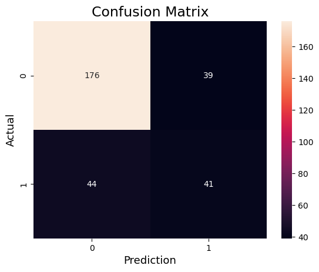

```
Accuracy: 0.7233333333333334
Precision: 0.5125
Recall: 0.4823529411764706
```

```python
### Code - the kNN classifier

from sklearn.metrics import confusion_matrix, accuracy_score, precision_score, recall_score

# Training the k-NN model
knn_model = KNeighborsClassifier(n_neighbors=3)
knn_model.fit(x_train, y_train)

# Making predictions on the test set
y_pred = knn_model.predict(x_test)

# Evaluating the model with confusion matrix, accuracy, precision and recall
conf_matrix = confusion_matrix(y_test, y_pred)
accuracy = accuracy_score(y_test, y_pred)
precision = precision_score(y_test, y_pred)
recall = recall_score(y_test, y_pred)

# Printing out the confusion matrix
sns.heatmap(conf_matrix,
            annot=True,
            fmt='g',
            xticklabels=['0','1'],
            yticklabels=['0','1'])
plt.ylabel('Actual',fontsize=13)
plt.xlabel('Prediction',fontsize=13)
plt.title('Confusion Matrix',fontsize=17)
plt.show()

# Displaying the accuracy, precision and recall
print("Accuracy:", accuracy)
print("Precision:", precision)
print("Recall:", recall)
```

a) In our case positive class represents the presence of the cardiovascular disease, while the negative class represents the absence of the cardiovascular disease. The top left cell in the matrix represents the correctly predicted instances of the negative class (True Negative). The top right cell represents the incorrectly predicted instances as positive when they were negative (False Positive). The bottom left represents the incorrectly predicted instances as negative when they were positive (False Negative). Finally, the bottom right represents the correctly predicted instances of the positive class (True Positive). b) Based on the confusion matrix, it can be said that the model performs better with the negative class in which we do not have a case of cardiovascular disease. The differences could arise of the fact that we have '0' cases more than the '1' cases, which allows model to learn about the patterns that lead to '0' case. The accuracy is the ratio of correctly predicted instances to the total instances, which is 0.723, which can be considered as 'decent', but it is encouraged to improve this value. The precision value answers the question of 'when it predicts yes, how often is it?', and the value for this is 0.512, which is totally unsatisfactory. Recall attempts to find an answer for the question of 'What proportion of actual positives was identified correctly?', and the result for it 0.482, which is again very low value. c) In our dataset, there are more healthy patients than the one with the cardiovascular disease, which leads to class imbalance in our dataset. The accuracy can be misleading metric in the datasets with class imbalance.

You randomly divided the data into two sets, one for training the k-NN model and the other for evaluating its performance. However, randomness is not the thing we really need, and in fact, it's not something we even desire. Instead, what we do want is to keep track of each step we're making and exporing. This said, the *reproducibility* of the results is extremely important in research. To achieve this, we can utilize a random seed, with which we can re-run the codes and get the exact same results than before.

For example, we can use a fixed seed when we're shuffling the data before splitting it into training and test sets. This ensures that when we're re-runing the code, we obtain exactly the same partitions of the data in each split.

**Exercise 1 E)**

Initialize 1000 random seeds and continue with the k-NN model ($k=3$): Perform 1000 different train-test splits using these seeds and store the accuracies from each split. Plot the accuracies in a histogram, and discuss your results.

*Tip: You can add the accuracy from the previous exercise in the plot by drawing a vertical line with the function `matplotlib.axes.Axes.axvline(<accuracy>)` if you want!*

```python
### Code - Initialization of the 1000 fixed seeds

# Generating 1000 random seeds and storing them in 'random_seeds'
random_seeds = set(np.random.randint(1, 10000, size=1000))
```

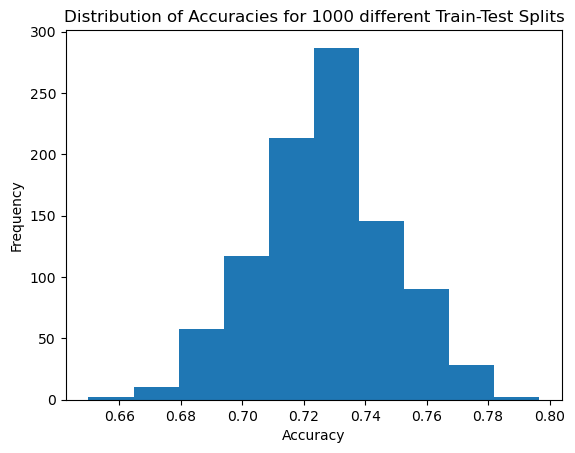

```python
### Code - 1000 different train-test-splits

# Creating a set for storing accuracies
accuracies = []

# Performing 1000 train-test splits and training k-NN model
for current_seed in random_seeds:

    # Doing train-test split with current_seed
    x_train, x_test, y_train, y_test = train_test_split(features, labels, test_size=0.2, random_state=current_seed)

    # Creating a k-NN model with k=3
    knn_model = KNeighborsClassifier(n_neighbors=3)

    # Training the model
    knn_model.fit(x_train, y_train)

    # Making predictions on the test set
    y_pred = knn_model.predict(x_test)

    # Calculating accuracy
    accuracy = accuracy_score(y_test, y_pred)

    # Storing accuracy
    accuracies.append(accuracy)

# Plot the histogram of accuracies
plt.hist(accuracies)
plt.xlabel('Accuracy')
plt.ylabel('Frequency')
plt.title('Distribution of Accuracies for 1000 different Train-Test Splits')
plt.show()
```

The values of Accuracy ranges from 0.66 to more than 0.79, which suggests slightly unstable and inconsistent model performance. The average performance of the model is around 0.73, which can be considered as decent.

One really common evaluation metric is the area under the receiver operating characteristic (AUROC, AUC or AUC-ROC). It provides a measure of a model's ability to distinguish between classes, especially in binary classification tasks between the *positive class* and the *negative class*. (There sure are multiclass and multilabel cases too, but they are out of scope here.)

In our case, individuals who have a CVD form the positive class. As the name of the measure suggests, it combines two keys aspects to interpret a model's performance: ROC curves are about the trade-off between the true positive rate and the false positive rate, the former representing the model's ability to correctly identify individuals with a CVD (true positives) and the latter measuring the model's tendency to incorrectly classify individuals without a CVD as if they have the disease (false positives). Thus, the area beneath the curve is simply the AUROC, a single numerical value, that summarizes the overall performance.

**Exercise 1 F)**

Evaluate the performance of the trained k-NN model by computing the AUROC and plotting the related curve. Draw also the line for random guesses.

- How well does the k-NN model perform in distinguishing between healthy individuals and those with a CVD?

*Tip: You should not use the predicted labels in this exercise.*

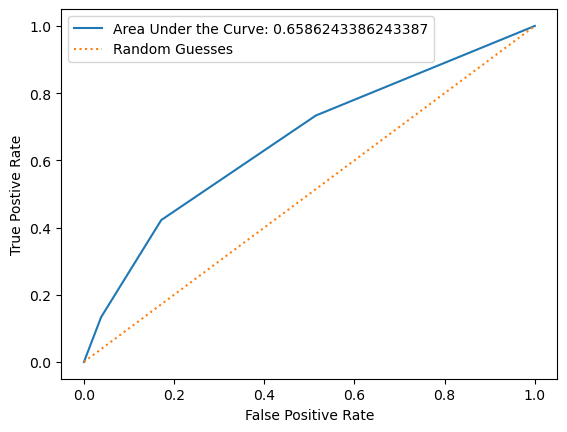

```python
### Code - ROC curve and AUROC

from sklearn.metrics import roc_curve, auc
from sklearn.preprocessing import label_binarize
from sklearn import metrics

# Using the model to predict probability that given y value is 1
y_pred_proba = knn_model.predict_proba(x_test)[:, 1]

# Calculating AUC of model
auc = metrics.roc_auc_score(y_test, y_pred_proba)

fpr, tpr, _ = roc_curve(y_test, y_pred_proba)

plt.plot(fpr, tpr, label= 'Area Under the Curve: {}'.format(auc))
plt.plot([0,1],[0,1], linestyle='dotted', label = 'Random Guesses')
plt.ylabel('True Postive Rate')
plt.xlabel('False Positive Rate')
plt.legend()
plt.show()
```

The AUROC values is 0.658, which can be described as decent, however there is room for improvement. I would say based on the AUROC value, the model performs decently in distinguishing between healthy individuals and those with a CVD, however I would not encourage the use of this specific model in the real-world cases.

## 2. Classification accuracy using leave-one-out cross-validation

While the train-test split may provide us with an unbiased estimate of the performance, we only evaluate the model once. Especially when dealing with small datasets, a test set itself will be very small. How can we be sure that the evaluation is accurate with this small test set and not just a good (or bad) luck? And what if we'd like to compare two models and the other seems to be better -- how can we be sure that it's not just a coincidence?

Well, there's a great help available and it's called cross-validation. With its help, we can split the dataset into multiple different training and test sets, which allows us to evaluate models across various data partitions. This time, we'll take a closer look at the leave-one-out cross-validation.

**Exercise 2**

Let's keep the focus on detecting the CVD, so once again we utilize the k-NN model (with $k=3$) to predict the precense of the disease. Now, apply leave-one-out cross-validation to assess whether the k-NN model is suitable for addressing the problem. You may use the entire dataset on this task.

- What can you say about the accuracy compared to the previous task?
- What do you think: Does the k-NN model work for the problem in hand? Explain your answer.

*Tip: This sure can be done manually, but `cross_val_score` is quite a handy function too.*

```python
### Code - Leave-one-out cross-validation

from numpy import mean
from numpy import absolute

# collecting the features as an array named features
features = cardio_sample.drop(columns=['cardio'])

# collecting the target variable as an array named labels
labels = cardio_sample['cardio']

# Creating a list of the names of the numerical features in the given dataframe
numerical_features = ["age", "height", "weight", "ap_hi", "ap_lo"]

# standardizing the numerical features in features data
features[numerical_features] = scale(features[numerical_features])

# Building our model
knn_model = KNeighborsClassifier(n_neighbors=3)


# Defining cross-validation method to use
cv = LeaveOneOut()

# using LOOCV to evaluate the model
scores = cross_val_score(knn_model, features, labels, scoring = 'accuracy', cv=cv, n_jobs=-1)

print(mean(absolute(scores)))
```

```
0.722
```

Our new value is quite similar to the previous accuracy value, there is very slight difference.Thus Our evaluation was accurate and we did not have extraordinary luck, when we used the train-test split b) The accuracy value is 0.722, which can be considered as decent. I would say that the K-NN model works decently based on the metrics of accuracy, however it is also important to consider other relevant metrics and comparisons

## 3. Model selection with leave-one-out cross-validation

So far, we've trained one model at a time and I've given the value of k for you. Accuracy is what it is (no spoilers here), but could we still do a little better? Let's explore that possibility through a process known as hyperparameter tuning. The cross-validation is especially important tool for this task. Note here, that model selection and model evaluation (or assessment) are two different things: We use model selection to estimate the performance of various models to identify the model which is most likely to provide the "best" predictive performance for the task. And when we have found this most suitable model, we *assess* its perfomance and generalisation power on unseen data.

This time, we're going to train multiple models, let's say 30, and our goal is to select the best K-Nearest Neighbors model from this set. Most models come with various hyperparameters that require careful selection, and the k-NN model is no exception. Although we're talking about the number of neighbors here, it's important to note that k-NN also has several other hyperparameters. However, for the sake of simplicity, this time we'll focus solely on fine-tuning the number of nearest neighbors, that is, the value of k.

Let's focus on the model selection part here for the sake of comprehending the cross-validation itself. We'll get later on the whole pipeline, which also includes model assessment.

**Exercise 3**

Find the optimal k value from a set of $k=1...30$ using leave-one-out cross-validation. Plot the accuracies vs. the k values. Again, you may use the entire dataset.

- Which value of k produces the best accuracy when using leave-one-out cross-validation? Compare the result to the previous model with $k=3$.
- If the number of k is still increased, what is the limit that the accuracy approaches? Why?
- Discuss the impact of choosing a very small or very large number of neighbors on the k-NN model's ability to distinguish between the healthy individuals and the ones with CVD.

```python
### Code - Select best model

# Creating a list of k values from 1 to 30
k_values = [i for i in range (1,31)]

# Creating an empty list to store the scores
scores = []

# Creating a KNeighborsClassifier object with every value in k_values with a loop
# And calculating the accuracy of each model and appending it to the scores list
for k in k_values:
    cv = LeaveOneOut()
    knn = KNeighborsClassifier(n_neighbors=k)
    score = cross_val_score(knn, features, labels, cv=cv)
    scores.append(np.mean(score))

# Printing the maximum accuracy value
print('The maximum accuracy value is', max(scores))
```

```
The maximum accuracy value is 0.758
```

```
28
```

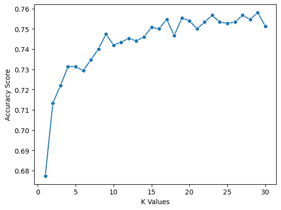

```python
### Code - Plot the accuracies vs. the values for k

print(scores.index(max(scores)))


# Generating the graph
sns.lineplot(x = k_values, y = scores, marker = 'o')

# Setting the X label
plt.xlabel("K Values")

# Setting the Y Label
plt.ylabel("Accuracy Score")
```

## 4. Training and testing on the same dataset

*Note that this should never be done outside of this exercise! You have been warned.*

Oh, but what if we just trained a model using the *entire* dataset? Wouldn't we like to use as much data as possible to discover the underlying patterns in the data so why not to use all of it?

**Exercise 4**

This is quite straightforward: Train 30 k-NN models ($k = 1...30$ ) using the whole dataset and evaluate the trained models using, again, the whole dataset. Create a plot that displays the accuracies against the corresponding k values. Include the accuracy values from the previous task in the same figure.

- What's the optimal value for k now and why's that? How would you interpret the reliability of the predictions?
- Explain why you should never use the same dataset for training and testing.

```python
### Code - Train with whole data

#create a range of k values
k_values = [i for i in range (1,31)]

#create a list to store the accuracies for the new models
new_accuracies = []

#train and evaluate 30 k-NN models using the whole dataset
for k in k_values:

    #train a k-NN model for each k value
    knn_model = KNeighborsClassifier(n_neighbors = k)

    #train the model on the whole dataset
    knn_model.fit(features, labels)

    #make predictions on the whole dataset
    y_pred = knn_model.predict(features)

    #calculate the accuracy for the current k
    accuracy = accuracy_score(labels, y_pred)

    #add the accuracy for the current k to the list of the accuracies for all the models
    new_accuracies.append(accuracy)
```

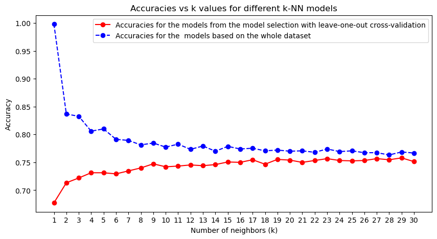

```python
### Code - Plot results

#plot the accuracies vs k values (k = 1,...,30)
plt.figure(figsize = (10, 5))

#plot the accuracy values from the previous task
plt.plot(k_values, scores, marker = 'o', linestyle = '-', color = 'red', label = 'Accuracies for the models from the model selection with leave-one-out cross-validation')

#plot the accuracy values from the new models
plt.plot(k_values, new_accuracies, marker = 'o', linestyle = '--', color = 'blue', label = 'Accuracies for the  models based on the whole dataset')

#add the title
plt.title('Accuracies vs k values for different k-NN models')

#add the label for the x-axis
plt.xlabel('Number of neighbors (k)')

#add the label for the y-axis
plt.ylabel('Accuracy')

#set the current tick locations and labels of the current tick locations and labels of the x-axis to the different k values
plt.xticks(k_values)

#add the legend
plt.legend()

#display the plot
plt.show()
```

The optimal value for the k is 1, now, and it has around 100% accuracy. This result is due to the fact that we used the entired dataset for both test and training data, which led us to the overfitting. When the k was 1, the model assigned the label of each data to the label of its nearest neighbor, which was the exact same point. In training data, the model just memorized the label of each data in the case of k=1, therefore it achieved 100% accuracy in the test data which was entirely identical to the training data. The reliability of this model is really low, since it can only achieve this accuracy in this test set which is identical to the training set. If a new and totally different test set is introduced, it is highly likely that the model will make incorrect predictions. b) The same dataset should not be used for the test and training set, because the model will likely to be overfitted and biased, and make very poor predictions on the data which is different from the training data.

## 5. Comparison of ridge regression and k-NN regression

The previous exercises were about classification. Now, we are ready to see another kind of supervised learning - regression - as we are changing our main goal from predicting discrete classes (healty/sick) to estimating continuous values. The following exercises are going to involve utilizing two different regression models, Ridge Regression and K-Nearest Neighbors (k-NN) Regression, and our goal is to evaluate and compare the performances of these two models.

Let's change the dataset to make the following exercises more intuitive. The new dataset is about brushtail possums and it includes variables such as

- **sex**: Gender, either male (0) or female (1)
- **age**: Age in years
- **len_head**: Head length in cm
- **width_skull**: Skull width in mm
- **len_total**: Total length in cm
- **len_tail**: Tail length in cm
- **len_foot**: Foot length
- **len_earconch**: Ear conch length
- **width_eye**: Distance from medial canthus to lateral canthus of right eye, i.e., eye width
- **chest**: Chest grit in cm
- **belly**: Belly grit in cm

In this case, our target variable will be *the age of the possum*. The data for this exercise has been modified from the original source.

There's the code chunk for loading data provided again. Again, the data file should be located in the same directory as this notebook file!

```python
### Loading code provided
# ------------------------------------------------------
# The data file should be at the same location than the
# exercise file to make sure the following lines work!
# Otherwise, fix the path.
# ------------------------------------------------------

# Data path
data_path = r'C:\Users\Comp-servis\Desktop\ex2_possum_data.csv'

# Load the data
possum_data = pd.read_csv(data_path)
```

Regression allows us to examine relationships between two or more variables. This relationship is represented by an *equation*, which itself represents how a change in one variable affects another on average. For example, we could examine how a change in possum's total length affects, on average, its estimated age.

We start by examing those relationships between the variables in the given dataset.

**Exercise 5 A)**

Plot pairwise relationships between the age variable and the others where you color the samples based on the sex variable.

- Which body dimensions seem to be most correlated with age? And are there any variables that seem to have no correlation with it?
- Are there any differences in the correlations between males and females?

*Tip: `seaborn.pairplot()` is handy with the parameters `(x,y)_vars` and `hue`. You actually can fit a linear model to draw a regression line with the parameter `kind` set to `"reg"`.*

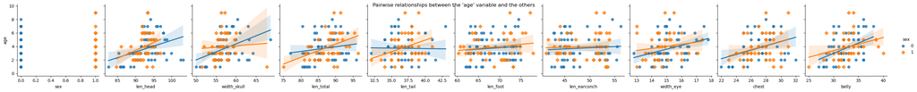

```python
### Code - Pairplot
sns.pairplot(possum_data, hue="sex", x_vars=['sex',"len_head", "width_skull", "len_total",'len_tail','len_foot','len_earconch','width_eye','chest','belly'],
    y_vars=["age"], kind = 'reg', height=3, markers=["o", "D"])
plt.suptitle("Pairwise relationships between the 'age' variable and the others")
```

The body dimensions that are most correlated with age are different based on the sex. For the males, 'len_head', 'width_skull', 'width_eye','chest','belly' and 'len_head' are the most correlated variables with age, while considering the females, those are 'len_head', 'len_total', 'len_tail' , 'chest' and 'belly'. Considering both sexes, the variables that do not show any correlation are 'len_foot' and 'len_earconch'. b) As shown before, the variables that correlate with the age differ for sexes, for example why there is a correlation with age for the 'width_skull' variable for males, this variable does not involve any significant correlation with age in females. Also, it is important to mention that, the degree of the correlations also differ for sexes.

Before the regression analysis itself, let's check that our dataset is in a proper format. We'll also perform the train-test split as we're going to first tune the hyperparameters for each model using the training set and test the overall performance of the chosen models using the test set.

**Exercise 5 B)**

Do you need to prepare the data a little? Explain your decision. Perform the train-test (80/20) split.

```
sex               int64
age             float64
len_head        float64
width_skull     float64
len_earconch    float64
width_eye       float64
len_foot        float64
len_tail        float64
chest           float64
belly           float64
len_total       float64
dtype: object
sex             0
age             0
len_head        0
width_skull     0
len_earconch    0
width_eye       0
len_foot        0
len_tail        0
chest           0
belly           0
len_total       0
dtype: int64
```

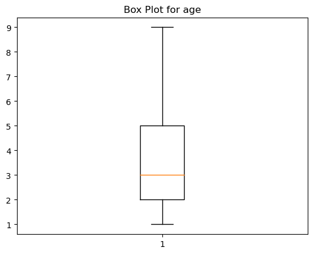

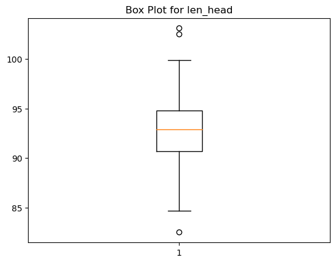

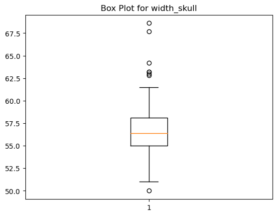

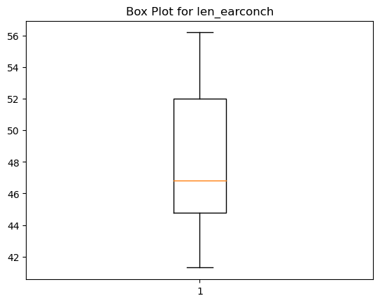

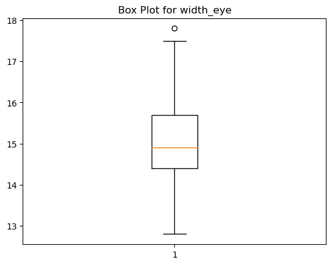

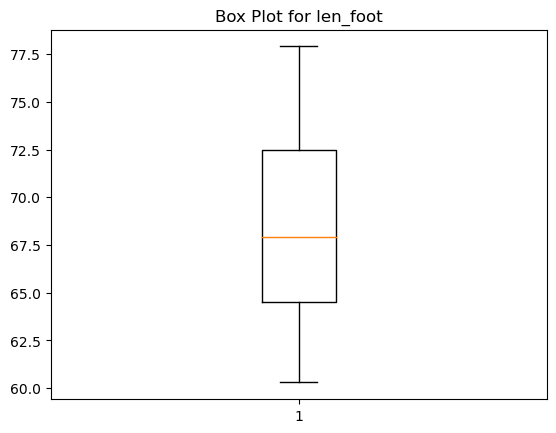

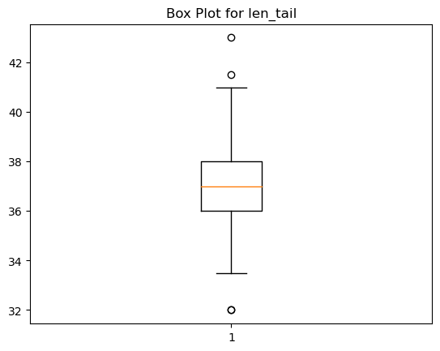

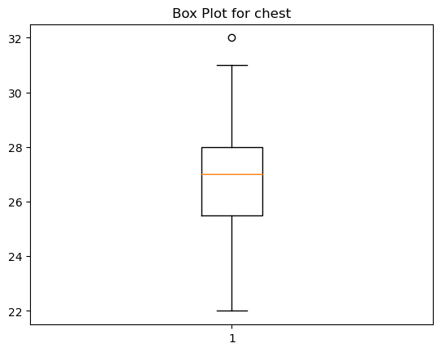

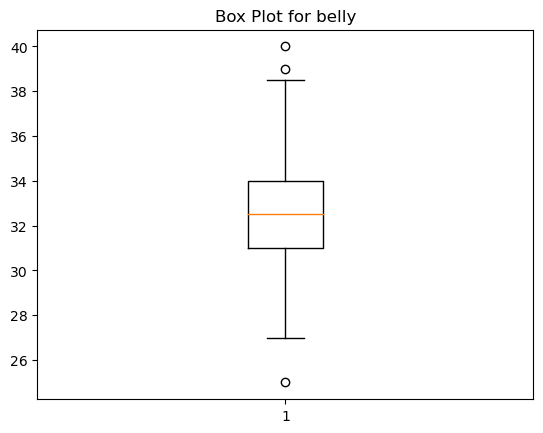

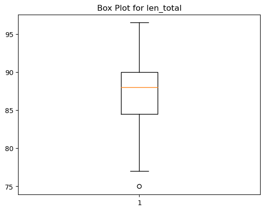

```python
### Code - Data preparation

# Displaying the data types of each variable
print(possum_data.dtypes)

# Looking for missing values in the dataframe
print(possum_data.isna().sum())

# Creating a dataframe consisting of only numerical features
possum_data_numeric = possum_data.drop(['sex'], axis = 1)

# Displaying a box plot for each feature to look for outliers
for column in possum_data_numeric.columns:
    plt.boxplot(possum_data_numeric[column])
    plt.title(f'Box Plot for {column}')
    plt.show()
```

The data is explored. First, the data types of each column in the data is checked, and it became clear that the 'sex' variable has integer data type, which was supposed to be binary. Then, the missing values are examined, and fortunately, there is no any missing value observed in the dataframe. Subsequently, the outliers are searched by displaying the box plot for each feature. Some features include outliers, however these are insignificant, thus it is decided to keep them in the data. Overall, the only change to make is to change the data type of the 'sex' variable to the binary.

```python
# Changing the data type of sex to binary
possum_data['sex'] = possum_data['sex'].astype('bool')

# Performing the test-train split

# Creating features data
features = possum_data.drop('age',axis = 1)

# Creating labels data
labels = possum_data['age']

# Performing the train and test split with the ratio of 8 : 2
x_train, x_test, y_train, y_test = train_test_split(features, labels, test_size = 0.2, random_state = 2310614)
```

Regarding the k-NN, we have already get familiar with the optimization of the k value. The idea behind the k-NN is the same as previously in classification, the output isn't a class anymore but a continuous value. So, for now, we can stick to the optimal k value. However, for Ridge Regression, we'll focus on the hyperparameter called $\lambda$ (read as 'lambda'), the regularization term (or penalty term or L2 penalty, how ever we'd like to call it), and try to find its optimal value for this task. After the model selection for both regression is performed, we compare the chosen models using a metric called mean absolute error (MAE).

**Exercise 5 C)**

Train multiple ridge regression models and k-NN regression models. For hyperparameters, use $\lambda=2^{-10}...2^{10}$ and $k=1...30$. Once again, use leave-one-out cross validation. Remember to use only the training dataset for model selection. Plot the optimal k values and lambdas versus corresponding MAEs (two different plots).

- Introduce the optimal hyperparameters for each regression model.
- How do you interpret the MAE in our case when the target variable is age?

*Note: In a `sklearn.linear_model.Ridge` class, lambda is called as "alpha" so don't get confused.*

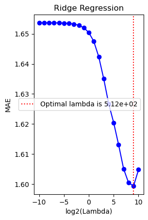

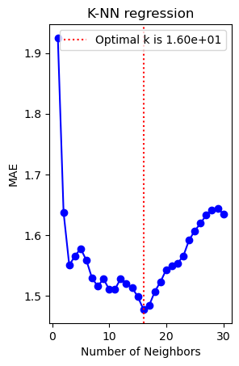

```python
### Code - CV for Ridge regression and k-NN regression
from sklearn.model_selection import cross_val_predict
from sklearn.metrics import mean_absolute_error

# Seting the range of the lambda hyperparameters
range_of_lambda = 2.0 ** np.arange(-10, 11)

# An empty set to collect MAE values for the performed ridge regression
mae_values_for_ridge = []

# Performing ridge regression models with different lambda hyperparameters and collecting the MAE values

for alpha in range_of_lambda:
    ridge_model = Ridge(alpha = alpha)
    cv=LeaveOneOut()
    y_pred = cross_val_predict(ridge_model, x_train, y_train, cv = cv)
    mae = mean_absolute_error(y_train, y_pred)
    mae_values_for_ridge.append(mae)

# Identifying the optimal lambda for ridge regression
optimal_lambda = range_of_lambda[np.argmin(mae_values_for_ridge)]

# Displaying the lambda values versus resultant MAEs
plt.figure()
plt.subplot(1, 2, 1)
plt.plot(np.log2(range_of_lambda), mae_values_for_ridge,color = 'blue', marker = 'o')
plt.title('Ridge Regression')
plt.xlabel('log2(Lambda)')
plt.ylabel('MAE')

# Displaying a vertical line for the optimal lambda
plt.axvline(np.log2(optimal_lambda), color = 'red', linestyle = ':', label = f'Optimal lambda is {optimal_lambda:.2e}')

# Showing legend
plt.legend()


# Setting the range of k (number of neighbors)
range_of_k = np.arange(1, 31)

# An empty set to collect MAE values for the performed k-nn
mae_values_for_knn = []

# Performing KNN models with different k's and collecting the MAE values
for k in range_of_k:
    knn_model = KNeighborsRegressor(n_neighbors = k)
    cv=LeaveOneOut()
    y_pred = cross_val_predict(knn_model, x_train, y_train, cv = cv)
    mae = mean_absolute_error(y_train, y_pred)
    mae_values_for_knn.append(mae)

# Find the optimal k for k-NN Regression
optimal_k = range_of_k[np.argmin(mae_values_for_knn)]

# Displaying a vertical line for the optimal k
plt.figure()
plt.subplot(1, 2, 2)
plt.plot(range_of_k, mae_values_for_knn,color = 'blue', marker = 'o')
plt.title('K-NN regression')
plt.xlabel('Number of Neighbors')
plt.ylabel('MAE')

# Displaying a vertical line for the optimal k
plt.axvline(optimal_k, color = 'red', linestyle = ':', label = f'Optimal k is {optimal_k:.2e}')

# Displaying Legend
plt.legend()
```

a) The Lambda that gives the lowest MAE is 512, while the optimal K is 16. b) The mean of absolute differences between the predicted and actual values is called MAE. In our case, the target variable is age. Thus, MAE represents the average absolute difference between the predicted and actual ages in years. If the MAE is 3, it means that there is an average 3 years difference between our predictions and actual age values.

The cross-validation was employed for model selection and at this point, we have the optimal hyperparameter settings for each model. Let's finally assess both models using the test set. To continue from this, we first fit the chosen models using the entire training, ensuring that the models are trained with the maximum available data.

**Exercise 5 D)**

Fit the chosen models with the whole training set. Evaluate the models using the test set and describe the results.

- How well did the models perform in estimating the possums' ages?
- So, what's the pitfall in here if you had compared the overall performance of the models based on the cross-validation MAEs and not the MAEs for the test set?

```python
## Code - Evaluating the selected models

# Building the model with optimal lambda
ridge_model = Ridge(alpha = optimal_lambda)

# Fiting the ridge regression model using the whole training set
ridge_model.fit(x_train, y_train)

# Performing predictions on the test set
y_pred_ridge = ridge_model.predict(x_test)

# Printing the mean absolute error
print('MAE for Ridge Regression is', mean_absolute_error(y_test, y_pred_ridge))

# Building the model with optimal k
knn_model = KNeighborsRegressor(n_neighbors = optimal_k)

# Fitting k-nn model using the whole training set
knn_model.fit(x_train, y_train)

# Performing predictions on the test set
y_pred_knn = knn_model.predict(x_test)

# Printing the mean absolute error
print('MAE for K-NN Regression is',mean_absolute_error(y_test, y_pred_knn))
```

```
MAE for Ridge Regression is 1.1860227300816926
MAE for K-NN Regression is 1.3095238095238095
```

a) The MAE for both models are decent, thus it could be said that both of models performed in a satisfactory degree. The comparison of the MAE values of these models reveal the fact that the Ridge Model performs slightly better than the K-NN model in terms of predicting the age values. b) The MAEs done with cross-validation helps us to identify the optimal hyperparameters, however MEAs based on the test data provided more realistic outcomes. The models built with cross-validation could be overfitted and potentially perform really poor on unseen data.

## BONUS: Feature selection - most useful features in predicting cardiovascular diseases

You can stop here and get the "pass" grade! To get the "pass with honors" grade, you need to do the following exercise. This means you'll get one bonus point for the exam.

The exercise is not as straightforward as the previous ones, and may require you to do some research of your own. You are also required to **explain** the steps you choose with your own words, and show that you tried to understand the idea behind the task. There's no single correct solution for this so just explain what you did and WHY you did it.

Unfortunately, due to the lack of resources and time, doctors can't measure all the values represented in the given cardio dataset. Fortunately, eager students are willing to help: Your task is to identify four [4] most useful features for predicting the presence of the CVD from the dataset. The steps needed for this job are presented above except the feature selection part. You must remember not to leak any information from the test set when selecting the features, i.e., you try to find those five features using only the training set.

Regarding the feature selection itself, you may choose your weapon from the three categories: filter methods, embedded methods or wrapper methods. Use two methods from two different category and compare their outputs. Bonus material about the methods is provided in Moodle.

Evaluate the model of your choice with the limited dataset by examining the confusion matrix and computing the accuracy and the AUROC.

**Discuss** your findings and results.

```python
## Code - Bonus task
```

\